# Lab 3B - Regression (Hard)

### 1. Explore the Data

1. Set the working directory to “C:/Workshop/Data”.

```r
setwd("C:/Workshop/Data")
```

2. Load the Rates.csv file into a data frame called “policies”.

```r
policies <- read.csv("Rates.csv")
```

3. Inspect the data.

```r
head(policies)
```

```
##   Gender State State.Rate Height Weight      BMI Age       Rate
## 1   Male    MA 0.10043368    184   67.8 20.02599  77 0.33200000
## 2   Male    VA 0.14172319    163   89.4 33.64824  82 0.86914779
## 3   Male    NY 0.09080315    170   81.2 28.09689  31 0.01000000
## 4   Male    TN 0.11997276    175   99.7 32.55510  39 0.02153204
## 5   Male    FL 0.11034460    184   72.1 21.29608  68 0.14975000
## 6   Male    WA 0.16292470    166   98.4 35.70910  64 0.21123703
```

4. Summarize the data.

```r
summary(policies)
```

```
##     Gender        State        State.Rate         Height
##  Female:956   CA     : 191   Min.   :0.0010   Min.   :150.0
##  Male  :986   TX     : 169   1st Qu.:0.1103   1st Qu.:162.0
##               FL     : 104   Median :0.1276   Median :170.0
##               NY     :  94   Mean   :0.1381   Mean   :169.7
##               IL     :  80   3rd Qu.:0.1443   3rd Qu.:176.0
##               OH     :  77   Max.   :0.3181   Max.   :190.0
##               (Other):1227
##      Weight            BMI             Age             Rate
##  Min.   : 44.10   Min.   :16.02   Min.   :18.00   Min.   :0.00100
##  1st Qu.: 68.60   1st Qu.:23.74   1st Qu.:34.00   1st Qu.:0.01475
##  Median : 81.30   Median :28.06   Median :51.00   Median :0.04628
##  Mean   : 81.16   Mean   :28.29   Mean   :50.84   Mean   :0.13806
##  3rd Qu.: 93.80   3rd Qu.:32.46   3rd Qu.:68.00   3rd Qu.:0.17269
##  Max.   :116.50   Max.   :46.80   Max.   :84.00   Max.   :0.99900
##
```

5. Load the RColorBrewer package.

```r
library(RColorBrewer)
```

6. Create a “Reds” color palette with 9 colors.

```r
palette <- brewer.pal(9, "Reds")
```

7. Create a scatterplot matrix using the following code.

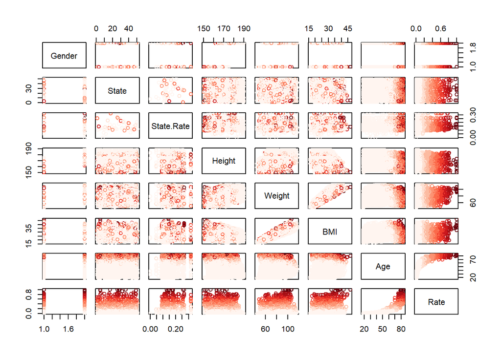

```r
plot(
  x = policies,
  col = palette[cut(
    x = policies$Rate,
    breaks = 9)])
```

8. Load the corrgram package.

```r
library(corrgram)
```

9. Create a correlogram of policies.

[figure not shown]

```r
corrgram(policies)
```

10. Inspect the correlation coefficients.

```r
cor(policies[3:8])
```

```
##              State.Rate      Height      Weight         BMI         Age
## State.Rate  1.000000000 -0.01652294 0.009233267  0.01924141  0.11234748
## Height     -0.016522938  1.00000000 0.238085304 -0.31696110 -0.16478131
## Weight      0.009233267  0.23808530 1.000000000  0.83962760  0.01167918
## BMI         0.019241409 -0.31696110 0.839627602  1.00000000  0.10231657
## Age         0.112347476 -0.16478131 0.011679178  0.10231657  1.00000000
## Rate        0.226852143 -0.12858150 0.060939196  0.14050657  0.78007905
##                  Rate
## State.Rate  0.2268521
## Height     -0.1285815
## Weight      0.0609392
## BMI         0.1405066
## Age         0.7800790
## Rate        1.0000000
```

11. Question: Which variable is most strongly correlated with mortality rate?
12. Get the correlation for age and rate.

```r
cor(
  x = policies$Age,
  y = policies$Rate)
```

```
## [1] 0.780079
```

13. Create a scatterplot of Age and Rate.

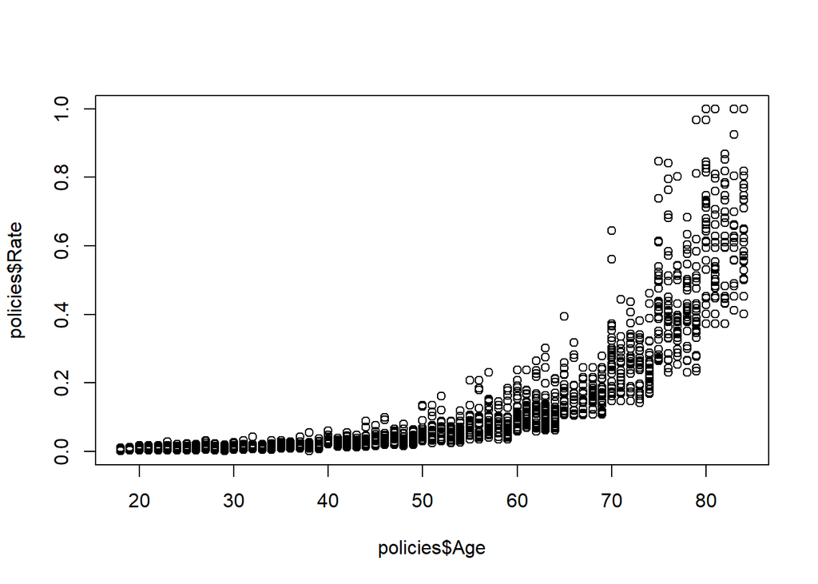

```r
plot(
  x = policies$Age,
  y = policies$Rate)
```

14. Question: Does this seem like a good relationship to model with linear regression? Why or why not?

### 2. Split the Data into Test and Training Sets

1. Set the seed to 42 to make randomness reproducable.

```r
set.seed(42)
```

2. Load the caret package

```r
library(caret)
```

3. Create training set indexes using the following code.

```r
indexes <- createDataPartition(
  y = policies$Rate,
  p = 0.80,
  list = FALSE)
```

4. Create the training set using the row indexes.

```r
train <- policies[indexes, ]
```

5. Create a test set using the remaining rows.

```r
test <- policies[-indexes, ]
```

6. Verify the number of rows in the training set.

```r
print(nrow(train))
```

```
## [1] 1555
```

7. Verify the number of rows in the test set.

```r
print(nrow(test))
```

```
## [1] 387
```

### 3. Predict with Simple Linear Regression

1. Create a simple linear regression model.

```r
simpleModel <- lm(
  formula = Rate ~ Age,
  data = train)
```

2. Draw a regression line on the plot.

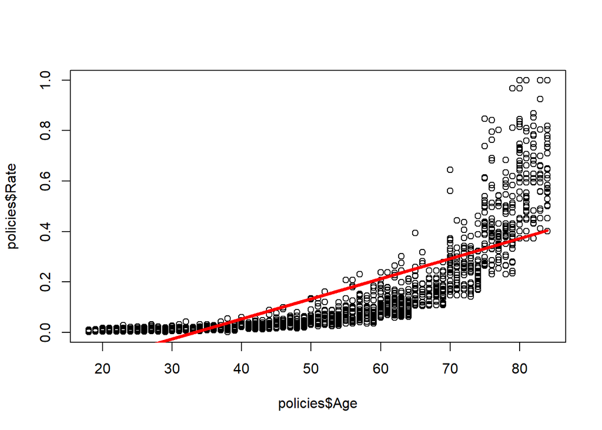

```r
plot(
  x = policies$Age,
  y = policies$Rate)

lines(
  x = train$Age,
  y = simpleModel$fitted,
  col = "red",
  lwd = 3)
```

3. Summarize the model.

```r
summary(simpleModel)
```

```
##
## Call:
## lm(formula = Rate ~ Age, data = train)
##
## Residuals:
##      Min       1Q   Median       3Q      Max
## -0.18237 -0.09092 -0.02208  0.06002  0.62697
##
## Coefficients:
##               Estimate Std. Error t value Pr(>|t|)
## (Intercept) -0.2650115  0.0087679  -30.23   <2e-16 ***
## Age          0.0079630  0.0001609   49.50   <2e-16 ***
## ---
## Signif. codes:  0 '***' 0.001 '**' 0.01 '*' 0.05 '.' 0.1 ' ' 1
##
## Residual standard error: 0.1236 on 1553 degrees of freedom
## Multiple R-squared:  0.6121, Adjusted R-squared:  0.6118
## F-statistic:  2450 on 1 and 1553 DF,  p-value: < 2.2e-16
```

4. Create predictions with the test set.

```r
simplePredictions <- predict(
  object = simpleModel,
  newdata = test)
```

5. Plot the predictions on a scatterplot of Age vs Rate.

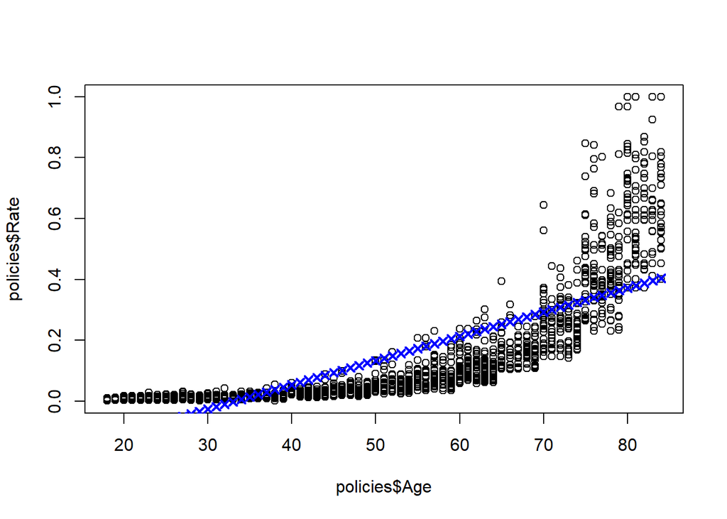

```r
plot(
  x = policies$Age,
  y = policies$Rate)


points(
  x = test$Age,
  y = simplePredictions,
  col = "blue",
  pch = 4,
  lwd = 2)
```

6. Compute the Root Mean Squared Error (RMSE) for the predictions.

```r
simpleRMSE <- sqrt(mean((test$Rate - simplePredictions)^2))
```

7. Inspect the RMSE.

```r
print(simpleRMSE)
```

```
## [1] 0.1148266
```

8. Question: Why was simple linear regression a poor choice for modeling this relationship?

### 4. Predict with Multiple Linear Regression

1. Create multiple linear regression model.

```r
multipleModel <- lm(
  formula = Rate ~ Age + Gender + State.Rate + BMI,
  data = train)
```

2. Inspect the model.

```r
summary(multipleModel)
```

```
##
## Call:
## lm(formula = Rate ~ Age + Gender + State.Rate + BMI, data = train)
##
## Residuals:
##      Min       1Q   Median       3Q      Max
## -0.24620 -0.08738 -0.02936  0.05979  0.60437
##
## Coefficients:
##               Estimate Std. Error t value Pr(>|t|)
## (Intercept) -0.4233471  0.0189843 -22.300  < 2e-16 ***
## Age          0.0077309  0.0001561  49.538  < 2e-16 ***
## GenderMale   0.0355968  0.0060606   5.873 5.21e-09 ***
## State.Rate   0.6258740  0.0686779   9.113  < 2e-16 ***
## BMI          0.0023340  0.0005240   4.454 9.03e-06 ***
## ---
## Signif. codes:  0 '***' 0.001 '**' 0.01 '*' 0.05 '.' 0.1 ' ' 1
##
## Residual standard error: 0.1188 on 1550 degrees of freedom
## Multiple R-squared:  0.6424, Adjusted R-squared:  0.6415
## F-statistic: 696.3 on 4 and 1550 DF,  p-value: < 2.2e-16
```

3. Create predictions with test set.

```r
multiplePredictions <- predict(
  object = multipleModel,
  newdata = test)
```

4. Plot the predictions on a scatterplot of Age vs Rate.

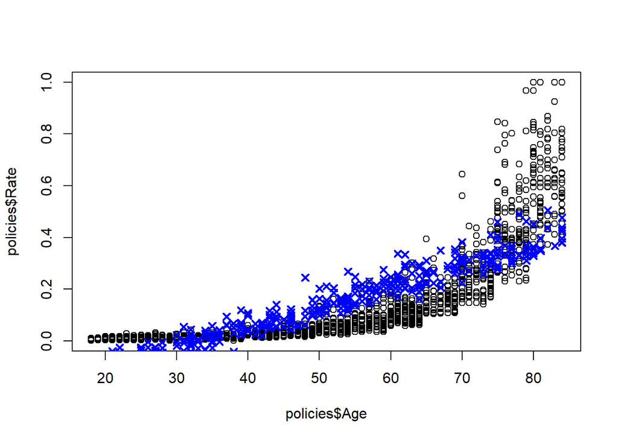

```r
plot(
  x = policies$Age,
  y = policies$Rate)

points(
  x = test$Age,
  y = multiplePredictions,
  col = "blue",
  pch = 4,
  lwd = 2)
```

5. Compute the RMSE for the predictions.

```r
multipleRMSE <- sqrt(mean((test$Rate - multiplePredictions)^2))
```

6. Inspect the RMSE.

```r
print(multipleRMSE)
```

```
## [1] 0.1102457
```

7. Question: What problems are there with using multiple linear regression to model this relationship?

### 6. Predict with Neural Network Regression

1. Create a function to scale and center.

```r
normalize <- function(x) {
  (x - min(x)) / (max(x) - min(x)) - 0.5
}
```

2. Create a function to undo scale and center.

```r
denormalize <- function(x, y) {
  ((x + 0.5) * (max(y) - min(y))) + min(y)
}
```

3. Scale and center the policies data set.

```r
scaledPolicies <- data.frame(
  Gender = policies$Gender,
  State.Rate = normalize(policies$State.Rate),
  BMI = normalize(policies$BMI),
  Age = normalize(policies$Age),
  Rate = normalize(policies$Rate))
```

4. Create a scaled training set using the row indexes.

```r
scaledTrain <- scaledPolicies[indexes, ]
```

5. Create a scaled test set from remaining indexes.

```r
scaledTest <- scaledPolicies[-indexes, ]
```

6. Load the nnet package.

```r
library(nnet)
```

7. Create a neural network regressor.

```r
neuralRegressor <- nnet(
  formula = Rate ~ .,
  data = scaledTrain,
  linout = TRUE,
  size = 5,
  decay = 0.0001,
  maxit = 1000)
```

8. Predict new values with the model.

```r
scaledPredictions <- predict(
  object = neuralRegressor,
  newdata = scaledTest)
```

9. Denormalize the predictions.

```r
neuralPredictions <- denormalize(
  x = scaledPredictions,
  y = policies$Rate)
```

10. Plot the predictions on scatterplot of Age vs Rate.

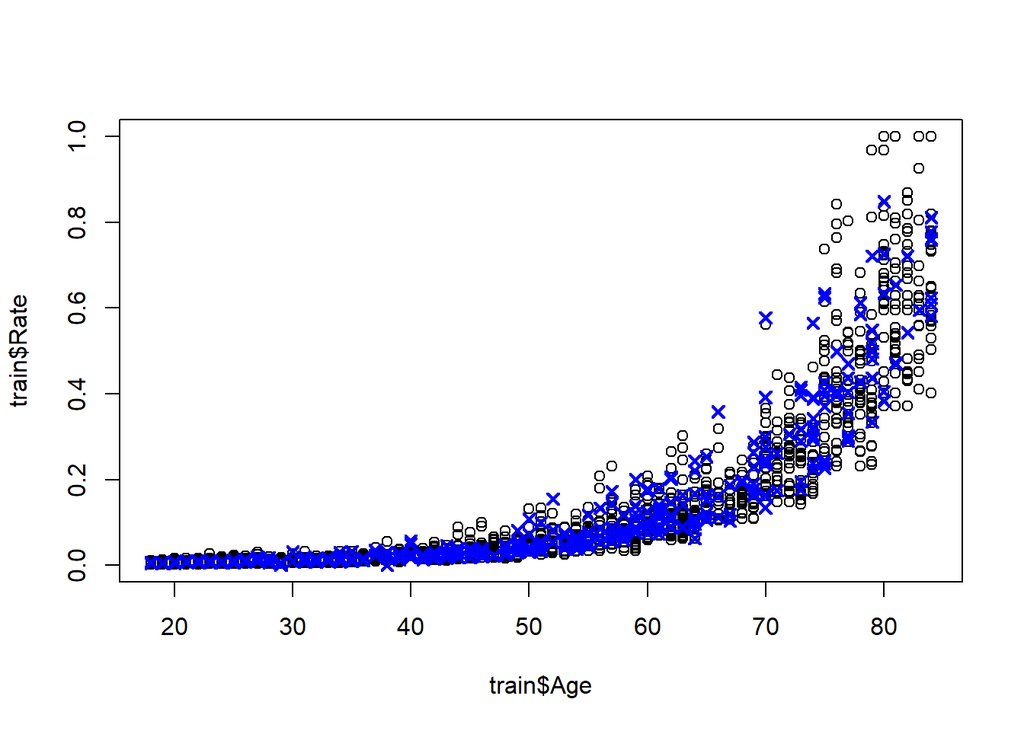

```r
plot(
  x = train$Age,
  y = train$Rate)

points(
  x = test$Age,
  y = neuralPredictions,
  col = "blue",
  pch = 4,
  lwd = 2)
```

11. Load the NeuralNetTools package.

```r
library(NeuralNetTools)
```

12. Plot the neural network.

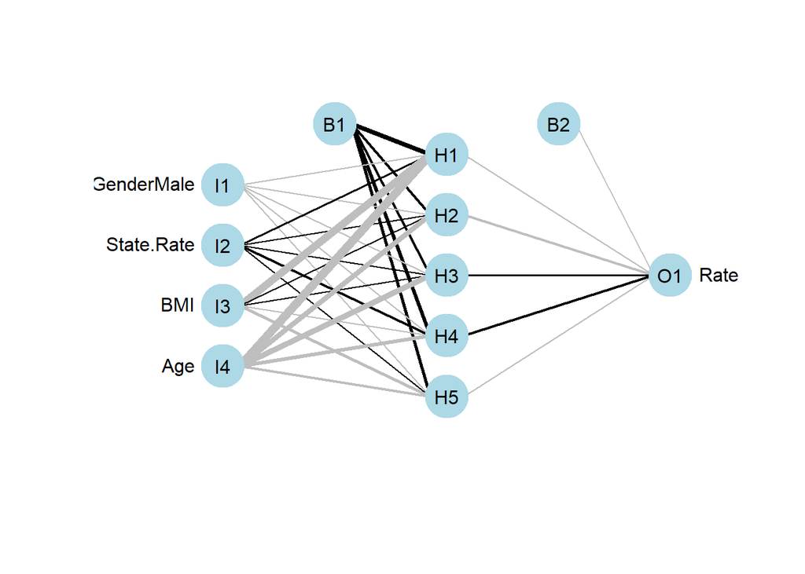

```r
plotnet(neuralRegressor)
```

13. Compute the RMSE for the predictions.

```r
neuralRMSE <- sqrt(mean((test$Rate - neuralPredictions)^2))
```

14. Inspect the RMSE

```r
print(neuralRMSE)
```

```
## [1] 0.039926
```

15. Question: Why was a neural network able to more accurately model this relationship?

### 7. Evaluate the Regression Models

1. Compare the RMSE for all three models.

```r
print(simpleRMSE)
```

```
## [1] 0.1148266
```

```r
print(multipleRMSE)
```

```
## [1] 0.1102457
```

```r
print(neuralRMSE)
```

```
## [1] 0.039926
```

2. Question: Which model would you choose? Why?